# cards_analysis

Brandon Leff

9/13/2019

# Data Preparation

First we must load in the data.

Now we must change the data type for the `rarity` and `type` variables turning them into factors.

Now let’s double check the data frame is correct now.

```
## # A tibble: 94 x 4
##    cardname        rarity type  elixir
##    <chr>           <fct>  <fct>  <dbl>
##  1 Ice Spirit      Common Troop      1
##  2 Skeletons       Common Troop      1
##  3 Bats            Common Troop      2
##  4 Fire Spirits    Common Troop      2
##  5 Spear Goblins   Common Troop      2
##  6 Goblins         Common Troop      2
##  7 Skeleton Barrel Common Troop      3
##  8 Goblin Gang     Common Troop      3
##  9 Bomber          Common Troop      3
## 10 Minions         Common Troop      3
## # … with 84 more rows
```

We must relevel the factors in order to understand the data better.

# Univariate Analysis

In order to understand the data better I will do quick plots to show the breakdown of the data.

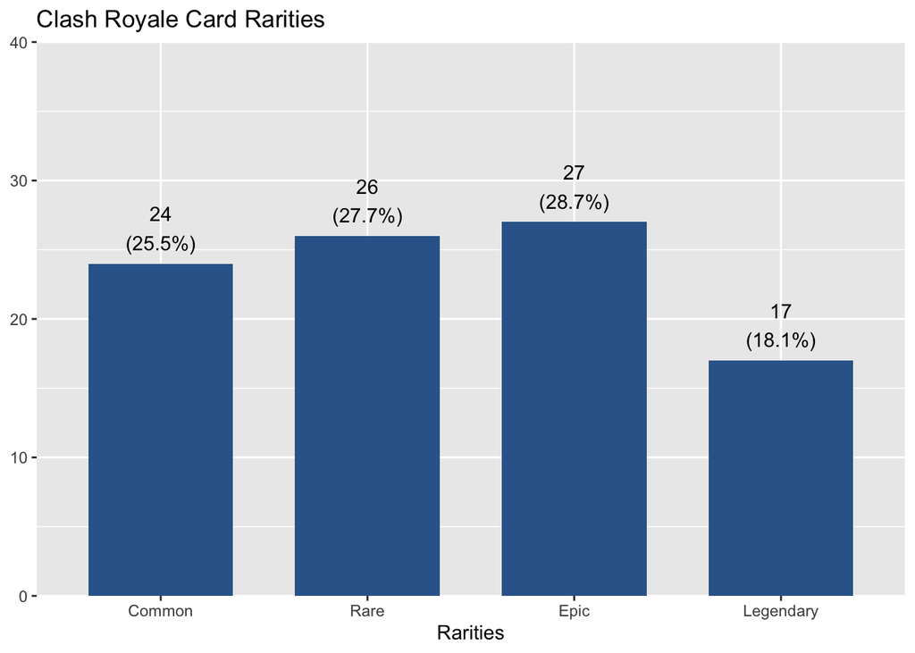

As seen in the graph above, the highest proportion of cards in Clash Royale are Epic cards with 27 (28.7%) cards in the game. This is followed by Rare cards with 26 (27.7%), Common cards with 24 (25.5%), and lastly Legendary cards with 17 (18.1%).

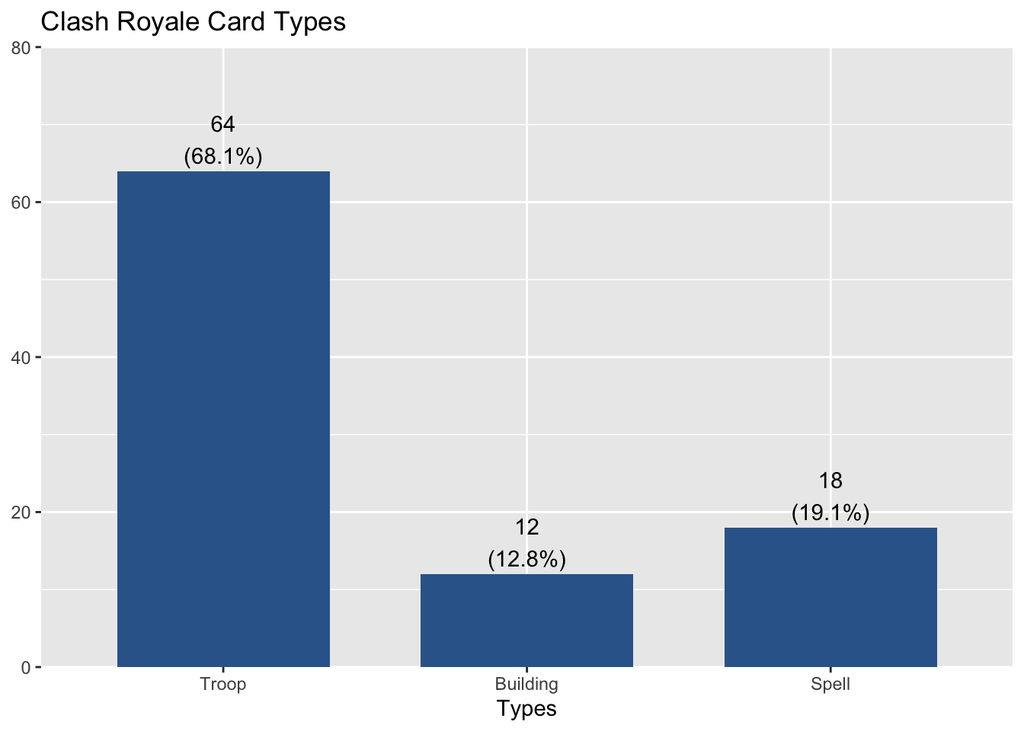

As seen in the graph above, the highest proportion of cards in Clash Royale are Troop cards with 64 (68.1%) cards in the game. This is followed by Spell cards with 18 (19.1%) and Building cards with 12 (12.8%).

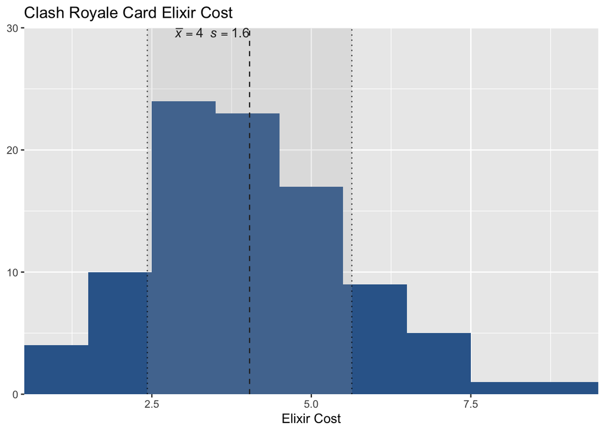

As seen in the graph above, the distribution of elixir cost for cards in Clash Royale is Unimodal with a small skew to the right. There is one card with an elixir cost of 8 and one card with an elixir cost of 9 which affects the mean by dragging it right. The mean is 4 elixir with a standard deviation of 1.6 elixir.

# Bivariate Analysis

Now I want to look into the breakdown of elixir cost within both rarity and type.

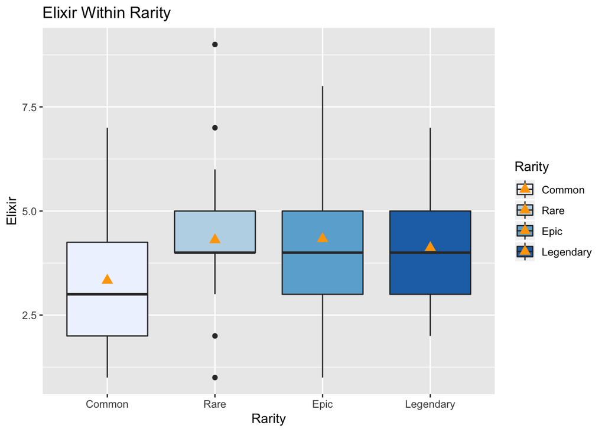